# American River

Sadie Gill, Mark Tompkins

December 19, 2018

## Future Data Improvements

- None planned

## Instream Spawning and Rearing Habitat

**Data Source:** [ARWA 2017](https://s3-us-west-2.amazonaws.com/cvpiahabitat-r-package/cvpia-sit-model-inputs/ARWA-702.pdf) and [USFWS 1985](https://s3-us-west-2.amazonaws.com/cvpiahabitat-r-package/cvpia-sit-model-inputs/AmericanRiver1985IFIM.PDF).

Instream spawning habitat for Fall Run Chinook Salmon and Steelhead in the American River is based on the spawning habitat suitability and availability analysis in the Lower American River Biological Rationale Development and Performance of the Modified Flow Standard (ARWA 2017). Instream juvenile rearing habitat for Fall Run Chinook Salmon is based on instream flow studies condicted by Mark Gard from the U.S. Fish and Wildlife Service. Both evaluations developed relationships between flow and suitable spawning and rearing habitat for the Lower American River.

### Spawning WUA

The Fall Run Chinook Salmon and Steelhead spawning habitat data from [ARWA 2017](https://s3-us-west-2.amazonaws.com/cvpiahabitat-r-package/cvpia-sit-model-inputs/ARWA-702.pdf) is contained in Attachment B, Table B-4 on page 91 and Figure B-8 on page 92 (Fall Run Chinook Salmon) and Attachment B, Table B-9 and Figure B-26 on page 107 (Steelhead).

#### Spawning WUA Plot

The following plot shows the composite weighted usable spawning area in square feet per thousand feet of river for Fall Run Chinook Salmon and Steelhead developed in the AWRA evaluation by combining the results for all evaluation reaches. These area per length rates are multiplied by the total spawning reach length mapped by the SIT.

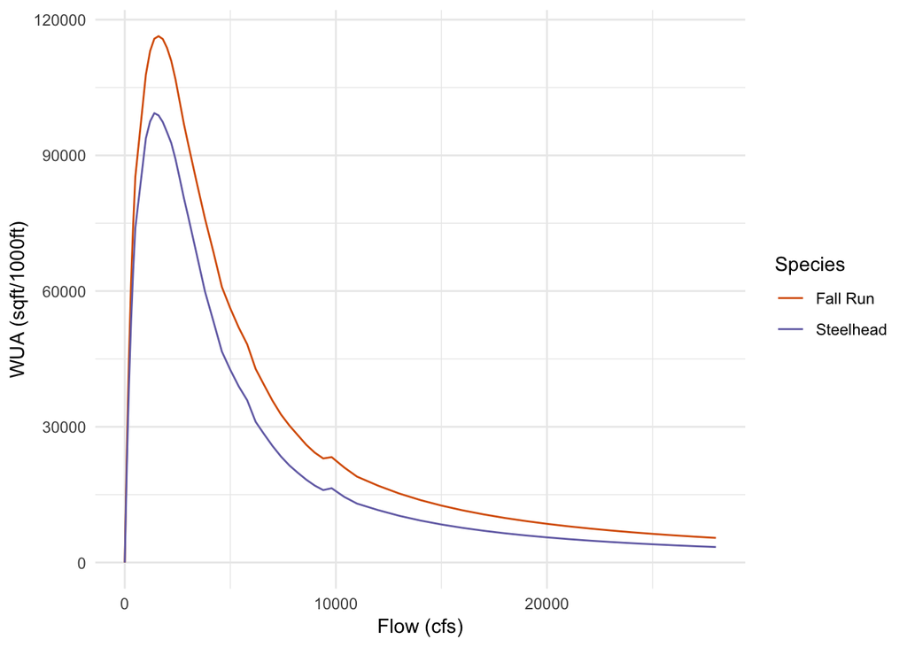

### Rearing WUA

The fry and juvenile instream rearing habitat weighted usable areas for Fall Run Chinook Salmon in the American River provided by Mark Gard (see ‘~/cvpiaHabitat/data-raw/mark_gard_data/IFIMWUA.xlsx’). The values contained in cells A35:D46 of the ‘American’ spreadhseet tab are the sums of the values from the instream flow evaluation reaches called Sailor Bar, Ancil Hoffman, Watt, and H Street. These values were divided by four to get composite instream rearing weighted usable area values in square feet per 1000 feet of river.

#### Rearing WUA Plot

The following plot shows the weighted usable rearing area in square feet per thousand feet of river for Fall Run Chinook Salmon fry and juvenile. These rates are multiplied by the total rearing reach length mapped by the SIT.

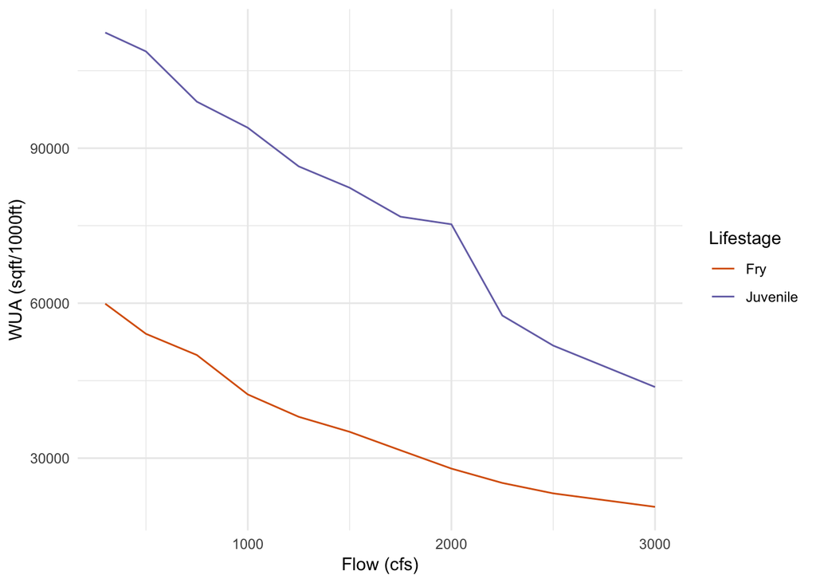